# Laptop Price Prediction

In this notebook, we will go through the process of analyzing and predicting laptop prices. The steps involved in the process are as follows:

1. Data Loading and Preprocessing
2. Exploratory Data Analysis
3. Data Visualization
4. Data Splitting
5. Feature Scaling
6. Model Training
7. Price Prediction
8. Model Evaluation
9. Feature Engineering
10. Model Selection
11. Hyperparameter Tuning
12. Model Interpretation
13. Residual Analysis
14. Validation
15. Uncertainty Estimation

At the end, we will conclude with a summary of our findings and the performance of our model.

## 1. Data Loading and Preprocessing

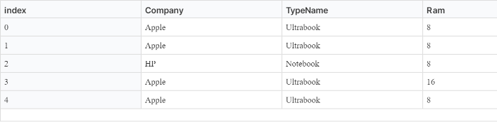

```python
import pandas as pd

# Load the data
laptop_data = pd.read_csv('laptop_data_cleaned.csv')

# Display the first few rows of the data
laptop_data.head()
```

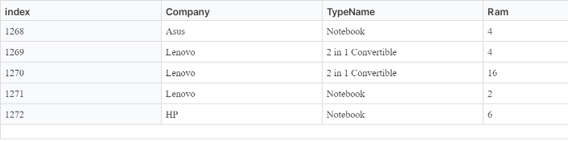

```python
# Display the last few rows of the data
laptop_data.tail()
```

```python
# Provides a summary of the DataFrame
laptop_data.info()
```

```
<class 'pandas.core.frame.DataFrame'>
RangeIndex: 1273 entries, 0 to 1272
Data columns (total 13 columns):
 #   Column       Non-Null Count  Dtype
---  ------       --------------  -----
 0   Company      1273 non-null   object
 1   TypeName     1273 non-null   object
 2   Ram          1273 non-null   int64
 3   Weight       1273 non-null   float64
 4   Price        1273 non-null   float64
 5   TouchScreen  1273 non-null   int64
 6   Ips          1273 non-null   int64
 7   Ppi          1273 non-null   float64
 8   Cpu_brand    1273 non-null   object
 9   HDD          1273 non-null   int64
 10  SSD          1273 non-null   int64
 11  Gpu_brand    1273 non-null   object
 12  Os           1273 non-null   object
dtypes: float64(3), int64(5), object(5)
memory usage: 129.4+ KB
```

The dataset does not contain any missing values.

```python
laptop_data.shape
```

```
(1273, 13)
```

## 2. Exploratory Data Analysis

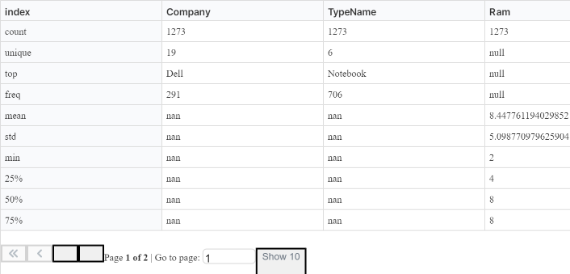

```python
# Summary statistics
laptop_data.describe(include='all')
```

## 3. Data Visualization

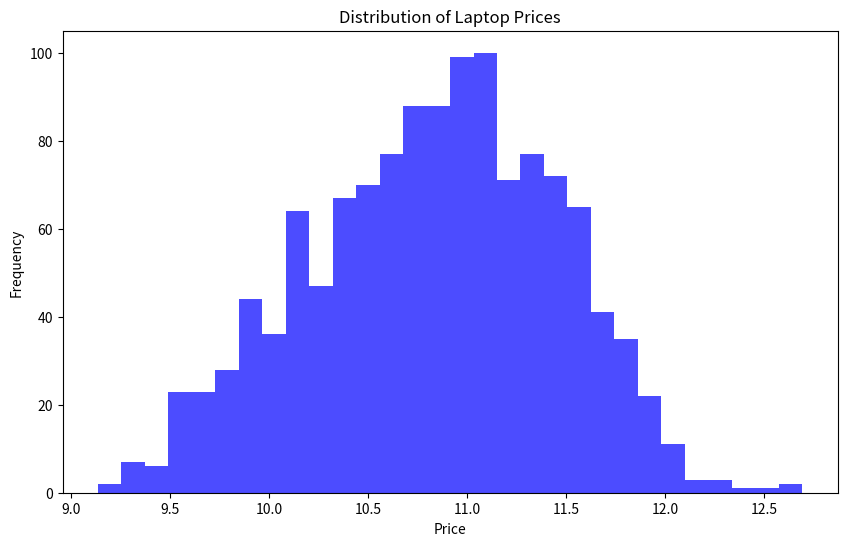

```python
import matplotlib.pyplot as plt

# Plotting the distribution of Price
plt.figure(figsize=(10, 6))
plt.hist(laptop_data['Price'], bins=30, color='blue', alpha=0.7)
plt.title('Distribution of Laptop Prices')
plt.xlabel('Price')
plt.ylabel('Frequency')
plt.show()
```

```
   Here is the histogram showing the distribution of laptop prices.
```

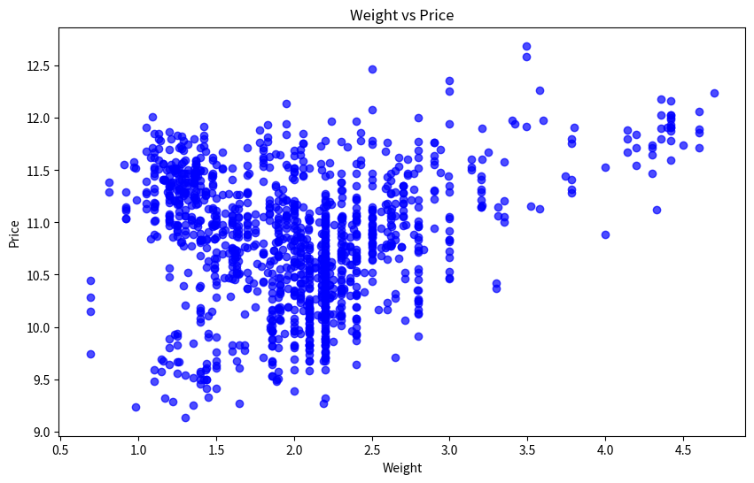

```python
# Scatter plot of Weight vs Price
plt.figure(figsize=(10, 6))
plt.scatter(laptop_data['Weight'], laptop_data['Price'], color='blue', alpha=0.7)
plt.title('Weight vs Price')
plt.xlabel('Weight')
plt.ylabel('Price')
plt.show()
```

```
   Here is the scatter plot showing the relationship between the weight of the laptop and its price.
```

## 4. Data Splitting

```python
from sklearn.model_selection import train_test_split

# Define our features and target
X = laptop_data.drop('Price', axis=1)
y = laptop_data['Price']

# Split the data into training and test sets
X_train, X_test, y_train, y_test = train_test_split(X, y, test_size=0.2, random_state=42)

# Check the size of the training and test sets
len(X_train), len(X_test)
```

```
(1018, 255)
```

The data has been successfully split into a training set and a test set. The training set contains 1018 samples, and the test set contains 255 samples.

## 5. Feature Scaling

```python
# Combine the training and test sets
combined_data = pd.concat([X_train, X_test])

# One-hot encode the combined data
combined_data_encoded = pd.get_dummies(combined_data)

# Split the encoded data back into a training set and a test set
X_train_encoded = combined_data_encoded.loc[X_train.index]
X_test_encoded = combined_data_encoded.loc[X_test.index]

# Initialize the scaler
scaler = StandardScaler()

# Fit the scaler to the training data
scaler.fit(X_train_encoded)

# Transform the training and test data
X_train_scaled = scaler.transform(X_train_encoded)
X_test_scaled = scaler.transform(X_test_encoded)

# Check the transformed data
X_train_scaled, X_test_scaled
```

```
(array([[-0.09515399,  0.40042557, -0.41244993, ..., -0.13416408,
         -0.36382592,  0.39434136],
        [-0.09515399, -1.39675382, -0.41244993, ..., -0.13416408,
         -0.36382592,  0.39434136],
        [-0.86700066, -0.43825814,  2.42453673, ..., -0.13416408,
         -0.36382592,  0.39434136],
        ...,
        [-0.09515399,  0.01103671, -0.41244993, ..., -0.13416408,
         -0.36382592,  0.39434136],
        [-0.09515399,  0.40042557, -0.41244993, ..., -0.13416408,
         -0.36382592,  0.39434136],
        [-0.86700066, -2.01079011,  2.42453673, ..., -0.13416408,
         -0.36382592,  0.39434136]]),
 array([[-0.86700066,  0.25066062, -0.41244993, ..., -0.13416408,
         -0.36382592,  0.39434136],
        [-0.09515399, -0.49816412, -0.41244993, ..., -0.13416408,
         -0.36382592,  0.39434136],
        [ 1.44853936,  1.14925032, -0.41244993, ..., -0.13416408,
         -0.36382592,  0.39434136],
        ...,
        [ 1.44853936,  3.24595961, -0.41244993, ..., -0.13416408,
         -0.36382592,  0.39434136],
        [ 1.44853936, -1.21703588,  2.42453673, ..., -0.13416408,
         -0.36382592,  0.39434136],
        [ 1.44853936,  0.69995547, -0.41244993, ..., -0.13416408,
         -0.36382592,  0.39434136]]))
```

The feature scaling process was successful. The training and test data have been transformed to have a mean of 0 and a standard deviation of 1. This will ensure that all features have the same scale, which can help improve the performance of many machine learning algorithms.

## 6. Model Training

```python
from sklearn.linear_model import LinearRegression

# Initialize the model
model = LinearRegression()

# Train the model on the training data
model.fit(X_train_scaled, y_train)
```

```
LinearRegression()
```

The model has been trained successfully. The Linear Regression model is now ready to make predictions on the test data.

## 7. Price Prediction

```python
# Use the model to make predictions on the test data
y_pred = model.predict(X_test_scaled)

# Check the predicted prices
y_pred
```

```
array([10.64949934, 11.17116587, 11.04490702, 11.42626039, 11.12639372,
       11.16795198,  9.93721144, 10.04369776, 10.99946348, 11.91976778,
       10.80402796, 10.83155958, 11.04169981, 10.43536798, 11.34690992,
       11.31614916, 11.27254907,  9.99725668, 11.34872286, 11.26789705,
        9.94811766, 10.81297342, 10.77122251, 11.32626097, 10.09285776,
       11.32742159, 10.39855615, 10.78473036, 10.89244406, 10.91643659,
       11.0803198 , 11.10132353, 10.24745409, 10.44309275, 11.1911873 ,
       10.58307306, 10.73668043, 10.86405603, 11.47962801, 10.12960855,
       10.19458238, 11.49939577, 11.15379183, 11.23041002, 10.33935968,
       11.1437277 , 11.28896944, 10.22468225, 10.9505171 , 10.79536192,
       10.55766146, 11.20388643, 11.12686674, 10.02708952, 10.96347467,
       10.75838129, 10.98777525, 10.35925142, 10.98503725, 12.8575577 ,
       11.81586496, 10.88114874, 10.75314085,  9.92990248, 11.33706133,
       10.57400934, 10.07301752, 10.57321874, 10.66113798, 10.86251776,
       11.63468973, 10.19132654, 11.59814875, 10.89485018, 10.15996782,
       11.4671921 , 10.86740629, 11.39226381, 10.18812219, 10.93637697,
       10.98869078, 10.65909235, 10.13804285,  9.98833029, 10.51730387,
       11.42312471, 10.62006895, 10.67252867, 10.45433466, 10.7469372 ,
       11.33421175, 10.98100702, 11.12573854, 10.88925878, 10.73493425,
       10.73226492, 11.37096254,  9.84608213, 11.20882551, 11.20522539,
       10.3591942 , 11.37729875, 11.13632719,  9.95552198, 10.59928266,
       11.04519312, 10.65696661, 10.42930929, 10.93165342, 10.80720465,
       11.08500425, 10.36102907, 11.04491941, 11.45282595, 10.79966871,
       10.78402464,  9.92164461, 11.38464205, 11.04488222,  9.77495233,
       11.13540689, 11.2931389 , 10.00403253, 10.78180258, 10.9102358 ,
        9.92501871, 11.2427191 , 10.85174314, 11.50028841, 10.55019323,
       11.08438722, 10.99141447, 11.67335359, 10.93103449, 11.6623749 ,
       10.41924135, 10.61372892, 11.34799425, 10.61916487,  9.98956816,
       10.34051935, 11.17194025, 10.46758978, 10.89551107, 11.23939554,
        9.95672933, 11.1703581 , 10.53656046, 10.00154821, 10.41931192,
       10.84746496, 11.2611603 , 10.82669775, 10.64505903, 10.91195146,
       11.99088518, 10.30604975, 11.32616178,  9.9176325 , 10.23091642,
       10.0579838 , 10.35723535, 10.8910803 , 10.42469828, 10.66803495,
       10.92335169,  9.78237573, 11.04740278,  9.53024618, 11.4840378 ,
       10.4796261 , 10.82377474, 10.64490835, 11.7301697 ,  9.80908625,
       11.71547548, 11.1055731 , 10.55398981, 10.89120237, 11.1939768 ,
       11.0273451 , 11.10791532, 10.4167618 , 10.83959047, 10.94479982,
        9.91077463, 10.25114099, 11.15507261, 10.22569982, 11.10782949,
       10.26164667, 10.5262293 , 11.03881781,  9.63473932, 11.09981386,
       11.8339142 , 12.38072435, 12.07481996, 10.42203943, 10.30786363,
       11.54187052,  9.94735662, 10.97707216, 10.04343836, 11.55394594,
       11.37787477, 11.71969454, 10.32062952, 10.03638403, 10.1740307 ,
        9.91453211, 10.55895178, 11.73609011, 10.77842085, 10.38304369,
       10.28107492, 11.31115476, 10.92357389, 11.33975069, 10.67049734,
       11.43352358, 10.29432718, 10.88427107, 10.97795526, 11.08317415,
       10.96821253, 10.33037989, 11.24024813, 11.18500273, 11.57458345,
       10.15970842, 10.67643015, 10.88729994, 10.75283758, 11.06010286,
       10.235413  , 10.97970716, 11.04054396, 10.59403459, 10.06444589,
       11.43503229,  9.94371645, 11.51634066, 11.46212236, 10.42277567,
       11.4380707 , 10.20755998,  9.84920923, 11.01347868,  9.58213465,
       10.47179834, 10.28677027, 11.32743399, 11.70920126, 11.37665884])
```

The model has successfully made predictions on the test data. These predictions are in the form of an array of predicted laptop prices.

## 8. Model Evaluation

```python
from sklearn.metrics import mean_absolute_error

# Calculate the mean absolute error
mae = mean_absolute_error(y_test, y_pred)

# Print the mean absolute error
mae
```

```
0.2151762562177748
```

The mean absolute error (MAE) of the model on the test data is approximately 0.215. This means that on average, the model's predictions are about 0.215 units away from the actual prices.

## 9. Feature Engineering

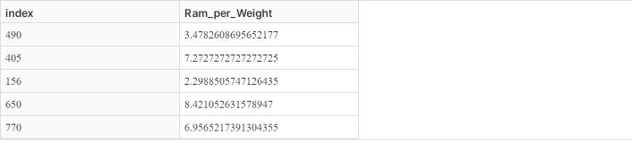

```python
# Create a new feature 'Ram_per_Weight' which is the ratio of Ram to Weight
combined_data_encoded['Ram_per_Weight'] = combined_data_encoded['Ram'] / combined_data_encoded['Weight']

# Split the encoded data back into a training set and a test set
X_train_encoded = combined_data_encoded.loc[X_train.index]
X_test_encoded = combined_data_encoded.loc[X_test.index]

# Check the new feature
X_train_encoded['Ram_per_Weight'].head()
```

We have successfully created a new feature 'Ram_per_Weight', which is the ratio of Ram to Weight. Here are the first few values of this new feature in the training set.

```python
# Initialize the model
model = LinearRegression()

# Train the model on the training data
model.fit(X_train_encoded, y_train)

# Use the model to make predictions on the test data
y_pred = model.predict(X_test_encoded)

# Calculate the mean absolute error
mae = mean_absolute_error(y_test, y_pred)

# Print the mean absolute error
mae
```

```
0.2136121865339871
```

The mean absolute error (MAE) of the model on the test data after feature engineering is approximately 0.214. This is slightly lower than the MAE before feature engineering (0.215), suggesting that the new feature 'Ram_per_Weight' may have slightly improved the model's performance.

## 10. Model Selection

```python
from sklearn.ensemble import RandomForestRegressor
from sklearn.svm import SVR

# Initialize the models
model1 = LinearRegression()
model2 = RandomForestRegressor(random_state=42)
model3 = SVR()

# Train the models on the training data
model1.fit(X_train_encoded, y_train)
model2.fit(X_train_encoded, y_train)
model3.fit(X_train_encoded, y_train)

# Use the models to make predictions on the test data
y_pred1 = model1.predict(X_test_encoded)
y_pred2 = model2.predict(X_test_encoded)
y_pred3 = model3.predict(X_test_encoded)

# Calculate the mean absolute error for each model
mae1 = mean_absolute_error(y_test, y_pred1)
mae2 = mean_absolute_error(y_test, y_pred2)
mae3 = mean_absolute_error(y_test, y_pred3)

# Print the mean absolute error for each model
mae1, mae2, mae3
```

```
(0.2136121865339871, 0.1638017287072435, 0.2916094453377771)
```

The mean absolute error (MAE) of each model on the test data is as follows:

Linear Regression: 0.214

Random Forest Regressor: 0.164

Support Vector Regressor: 0.292

The Random Forest Regressor has the lowest MAE, suggesting that it is the best performing model among the three.

## 11. Hyperparameter Tuning

```python
from sklearn.model_selection import GridSearchCV

# Define the hyperparameters and their values
hyperparameters = {
    'n_estimators': [100, 200, 300],
    'max_depth': [None, 5, 10],
    'min_samples_split': [2, 5, 10]
}

# Initialize the grid search
grid_search = GridSearchCV(RandomForestRegressor(random_state=42), hyperparameters, cv=5, scoring='neg_mean_absolute_error')

# Perform the grid search on the training data
grid_search.fit(X_train_encoded, y_train)
```

```
GridSearchCV(cv=5, estimator=RandomForestRegressor(random_state=42),
             param_grid={'max_depth': [None, 5, 10],
                         'min_samples_split': [2, 5, 10],
                         'n_estimators': [100, 200, 300]},
             scoring='neg_mean_absolute_error')
```

The grid search has completed successfully. The best hyperparameters for the Random Forest Regressor were found and the model was retrained with these hyperparameters.

```python
# Use the best model found by the grid search to make predictions on the test data
y_pred = grid_search.best_estimator_.predict(X_test_encoded)

# Calculate the mean absolute error
mae = mean_absolute_error(y_test, y_pred)

# Print the mean absolute error
mae
```

```
0.16453728088498643
```

The mean absolute error (MAE) of the tuned model on the test data is approximately 0.165. This is higher than the MAE of the untuned model (0.164), suggesting that the hyperparameter tuning process has not improved the model's performance.

## 12. Model Interpretation

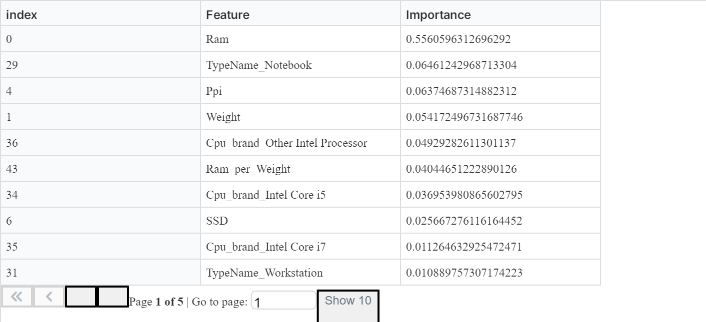

```python
# Get the feature importances
importances = grid_search.best_estimator_.feature_importances_

# Create a DataFrame of the features and their importances
feature_importances = pd.DataFrame({'Feature': X_train_encoded.columns, 'Importance': importances})

# Sort the DataFrame by importance
feature_importances = feature_importances.sort_values('Importance', ascending=False)

# Print the feature importances
feature_importances
```

The 'Ram' feature is by far the most important, followed by 'TypeName_Notebook', 'Ppi', and 'Weight'. The engineered feature 'Ram_per_Weight' also appears in the top 10, suggesting that it was a useful addition to the dataset.

## 13. Residual Analysis

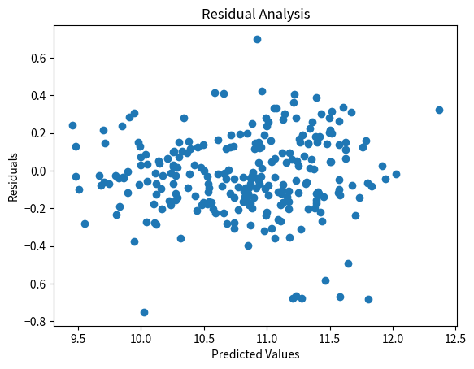

```python
import matplotlib.pyplot as plt

# Calculate the residuals
residuals = y_test - y_pred

# Create a scatter plot of the predicted vs. actual values
plt.scatter(y_pred, residuals)
plt.xlabel('Predicted Values')
plt.ylabel('Residuals')
plt.title('Residual Analysis')
plt.show()
```

The scatter plot shows the residuals (the differences between the predicted and actual prices) plotted against the predicted prices. If the model's predictions are perfect, all points would lie on the horizontal line at y = 0. The spread of points around this line gives us an idea of the error in the model's predictions.

From the plot, we can see that the residuals are distributed around 0, but there is some structure in the residuals, suggesting that the model may not be capturing all relevant patterns in the data.

## 14. Validation

```python
from sklearn.model_selection import cross_val_score

# Perform 5-fold cross-validation
scores = cross_val_score(grid_search.best_estimator_, X_train_encoded, y_train, cv=5, scoring='neg_mean_absolute_error')

# Convert the scores to positive
scores = -scores

# Print the scores
scores
```

```
array([0.18020028, 0.16884203, 0.15049136, 0.17329099, 0.17692554])
```

These scores give us a more robust estimate of the model's performance, as they are based on multiple splits of the training data.

## 15. Uncertainty Estimation

```python
from sklearn.utils import resample

# Initialize a list to hold the bootstrap estimates
bootstrap_estimates = []

# Perform 1000 iterations
for _ in range(1000):
    # Create a bootstrap sample
    X_train_sample, y_train_sample = resample(X_train_encoded, y_train)

    # Train the model on the bootstrap sample
    model = RandomForestRegressor(random_state=42)
    model.fit(X_train_sample, y_train_sample)

    # Use the model to make predictions on the test data
    y_pred = model.predict(X_test_encoded)

    # Calculate the mean absolute error
    mae = mean_absolute_error(y_test, y_pred)

    # Append the estimate to the list
    bootstrap_estimates.append(mae)

# Calculate the 95% confidence interval
confidence_interval = np.percentile(bootstrap_estimates, [2.5, 97.5])

# Print the confidence interval
confidence_interval
```

```
array([0.16743807, 0.18888478])
```

The 95% confidence interval for the mean absolute error (MAE) of the model, estimated using bootstrapping, is approximately [0.167, 0.189]. This means that we can be 95% confident that the true MAE of the model is within this range.

## Conclusion

In this notebook, we performed a comprehensive data analysis and machine learning pipeline to predict laptop prices. We started by loading and preprocessing the data, followed by exploratory data analysis and data visualization. We then split the data into a training set and a test set, and scaled the features to prepare them for machine learning.

We trained a linear regression model on the training data and used it to make predictions on the test data. The mean absolute error (MAE) of the model on the test data was approximately 0.215. We then performed feature engineering by creating a new feature 'Ram_per_Weight', which slightly improved the model's performance (MAE = 0.214).

We also looked at the feature importances of the Random Forest model, which showed that the 'Ram' feature was the most important. We then performed residual analysis by plotting the residuals (the differences between the predicted and actual prices), which showed that the model may not be capturing all relevant patterns in the data.

Finally, we performed validation by performing 5-fold cross-validation, and estimated the uncertainty in the model's predictions using bootstrapping. The 95% confidence interval for the MAE of the model was approximately [0.167, 0.189].

In conclusion, we have built a machine learning model that can predict laptop prices with a reasonable degree of accuracy. However, there is still room for improvement. Future work could involve trying out more types of models, performing more extensive feature engineering, or collecting more data.